# 13 Inférence Statistique: deux échantillons

### 13.5.1 Estimation de la différence de moyennes: données corrélées

L’estimation de la différence de moyennes pour échantillons corrélés se résume à l’estimation de la moyenne des différences. La procédure est donc identique à l’estimation d’une moyenne unique que nous avons étudiée antérieurement. En utilisant le ré-échantillonnage, on obtient l’intervalle de confiance suivant, illustré à la Figure 13.26:

```r
ns <- 100000
xb <- replicate(ns, mean(sample(dat$Diff, nrow(dat), replace = TRUE)))
```

[figure not shown]

Figure 13.26

```r
obs_diff <- md
xbd <- xb
qtl <- intc
p <- mean(abs(xbd) >= abs(obs_diff))
txt1 <- paste("$\\bar{d} = ", round(obs_diff, 3), "$")
txt2 <- paste("$p = ", round(p, 3), "$")
txt <- paste("$C\\left [", round(qtl[1], 3), "\\leq \\delta \\leq ", round(qtl[2], 3), "\\right ]=95\\%$")

h <- hist(xbd, breaks = "FD", plot = FALSE)
breaks <- h$breaks
counts <- h$counts

left_tail <- which(breaks >= min(xbd) & breaks < qtl[1])
right_tail <- which(breaks > qtl[2] & breaks <= max(xbd))

cols <- rep("lightblue", length(breaks))
cols[left_tail] <- "red"
cols[right_tail] <- "red"

hist(xbd,
     breaks = breaks,
     col = cols,
     border = "white",
     main = "Distribution d'échantillonnage\n de la moyenne des différences",
     sub = TeX(txt),
     cex.sub = 1.2,
     xlab = NULL)
max_count <- max(h$counts)

text(x = quantile(xbd, 0.001), y = max_count * 0.9,
     labels = TeX(txt1), adj = 0)
text(x = quantile(xbd, 0.001), y = max_count * 0.8,
     labels = TeX(txt2), adj = 0)
points(obs_diff, 0, pch = 17, col = "darkgreen", cex = 1.2)
```

Des résultats similaires peuvent s’obtenir à l’aide de la fonction **boot.paired.per()** de la librairie **wBoot**:

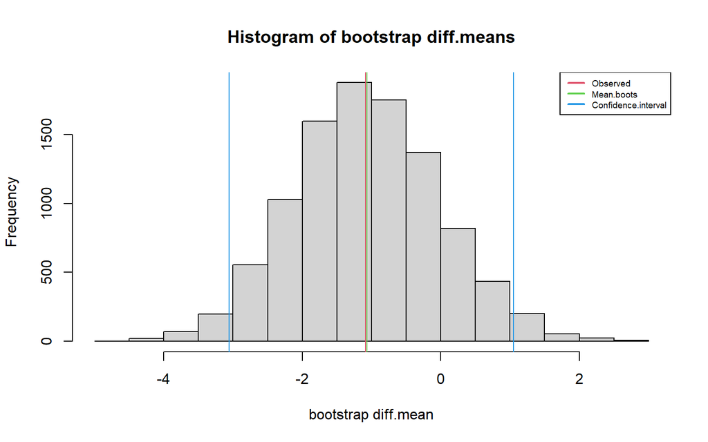

```
#>
#>
#>  RESULTS OF PERCENTILE BOOTSTRAP FOR DIFF.MEAN
#>
#>     SUMMARY Pop.1 Pop.2  n Statistic  Observed
#>  STATISTICS    x1    y1 25 diff.mean -1.085087
#>
#>  BOOTSTRAP Replications      Mean       SE   Bias Percent.bias
#>    SUMMARY         9999 -1.067686 1.052884 0.0174          1.6
#>
#>  CONFIDENCE Level      Type Confidence.interval
#>    INTERVAL   95% two-sided      (-3.056, 1.05)
```

```r
b.Diff = wBoot::boot.paired.per(x1,
                                y1,
                                conf.level = 0.95,
                                R = 9999)
print.boot.paired(b.Diff)
```

On obtiendra évidemment des résultats similaires en utilisant la fonction **boot.one.per()** sur l’ensemble des différences *d* plutôt que sur les observations originales:

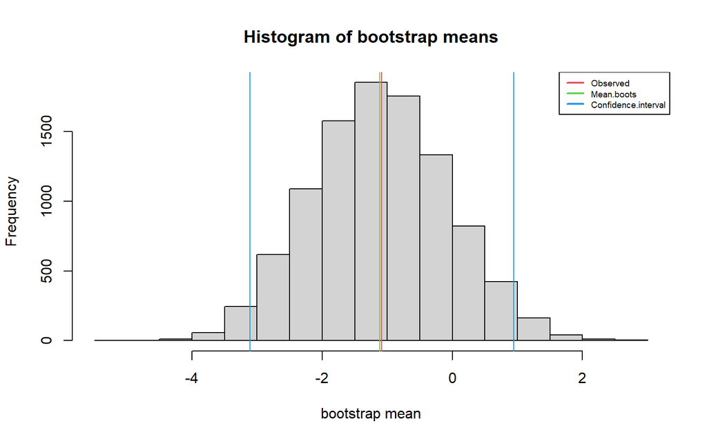

```
#>
#>
#>  RESULTS OF PERCENTILE BOOTSTRAP FOR MEAN
#>
#>     SUMMARY Variable  n Statistic  Observed
#>  STATISTICS        d 25      mean -1.085087
#>
#>  BOOTSTRAP Replications      Mean       SE    Bias Percent.bias
#>    SUMMARY         9999 -1.111439 1.038439 -0.0264         2.43
#>
#>  CONFIDENCE Level      Type Confidence.interval
#>    INTERVAL   95% two-sided    (-3.106, 0.9433)
```

```r
b.Diff = wBoot::boot.one.per(d,
                             mean,
                             conf.level = 0.95,
                             R = 9999)
print.boot.one(b.Diff)
```

### 13.5.2 Estimation: deux échantillons corrélés - Approche théorique

Formellement, le fait qu’il y ait corrélation entre les données observées sous deux conditions affecte la valeur de l’erreur-standard des différences de moyennes, par rapport à une situation où cette corrélation est nulle. En effet, pour des échantillons indépendants, l’erreur-standard des différences de moyennes a été définie par:

$$\sigma_{\bar X_1-\bar X_2}=\sqrt{\sigma_{\bar X_1}^2+\sigma_{\bar X_2}^2} \tag{13.20}$$

Par contre, s’il y a corrélation entre les variables $X_1$ et $X_2$, nous détenons des informations additionnelles de fait même de cette corrélation: les données obtenues d’un groupe fournissent des informations non seulement sur l’ensemble de ce groupe, mais aussi au sujet du groupe qui lui est apparié. Ces informations supplémentaires doivent donc être intégrées à l’estimation de l’erreur-standard des différences de moyennes, qui se définit par:

$$\sigma_{\bar X_1-\bar X_2}=\sqrt{\sigma_{\bar X_1}^2+\sigma_{\bar X_2}^2-2\rho\sigma_{\bar X_1}\sigma_{\bar X_2}} \tag{13.21}$$

Si la corrélation entre les observations ($\rho$) est nulle, le terme $-2\rho \sigma_{\bar X_1}\sigma_{\bar X_2}$ disparait de l’équation et nous retrouvons la définition de l’erreur-standard appropriée pour des échantillons indépendants. Dans le cas contraire, la valeur de l’erreur-standard sera réduite en fonction du degré de corrélation.

Mais il existe une manière plus simple de considérer l’estimation de la différence des moyennes: il suffit d’estimer la **moyenne des différences** ($d_i$)! Cette stratégie réduit le problème à l’estimation d’une moyenne unique, l’objectif est d’estimer la moyenne des différences observées entre les observations appariées, $d_i=X_i-Y_i$, plutôt que la différence des moyennes ($\bar X_1-\bar X_2$).

La distribution d’échantillonnage des moyennes, on le sait, est gaussienne, avec une moyenne ($\mu_{\bar X}$) égale à la moyenne de la population ($\mu_{X}$), et une erreur-standard égale à :

$$\sigma_{\bar X}=\frac{\sigma_X}{\sqrt n} \tag{13.22}$$

La distribution d’échantillonnage des différences de moyennes corrélées est donc également gaussienne, avec une moyenne ($\mu_{\bar D}$) égale à la moyenne des différences ($\mu_{D}$) au niveau de la population, et une erreur-standard égale à:

$$\sigma_{\bar d}=\frac{\sigma_d}{\sqrt n} \tag{13.23}$$

Nous connaissons donc déjà les détails de la procédure d’estimation. L’intervalle de confiance pour une différence de moyennes corrélées est défini par:

$$C[{\bar d}-t_{(dl;1-\alpha /2)}s_{\bar d}\le \mu_d \le {\bar d}-t_{(dl;1-\alpha /2)}s_{\bar d}] = 100(1-\alpha)\% \tag{13.24}$$

Revenant à l’exemple précédent, où les compétences en calcul au niveau Fondamental sont évaluées au début et à la fin de la session, afin de déterminer si l’enseignement reçu durant la session a permis d’améliorer les compétences des élèves, en calcul. Si l’enseignement n’a pas d’impact sur les compétences, alors la moyenne des différences sera près de 0 ($\mu_d=0$). Si l’enseignement a permis à la plupart des élèves d’améliorer leurs compétences, la moyenne des différences sera négative ($\mu_d<0$); dans le cas contraire, elle sera positive ($\mu_d>0$). De fait, $(\bar X_1 - \bar X_2)=\bar d$.

Le tableau Table 13.2 reproduit l’ensemble des observations et les statistiques descriptives pertinentes sont reproduites ci-dessous:

**Statistiques**:

- $\bar{X}_{Temps_1} = 60.723 \qquad s_{Temps_1} = 5.829$
- $\bar{X}_{Temps_1} = 61.808 \qquad s_{Temps_2} = 6.498$
- $\bar{D} = -1.085 \qquad \qquad s_{D} = 5.298$
- $r_{XY} = 0.635$

Finalement, l’intervalle de confiance pour la moyenne des différences, pour un niveau de confiance $(1-\alpha)=0.95$ est produit:

$$\begin{align}
C[{\bar d}-t_{(dl;1-\alpha /2)}s_{\bar d}\le \mu_d \le {\bar d}-t_{(dl;1-\alpha /2)}s_{\bar d}] &= 100(1-\alpha)\%\\
C[-1.085-2.064(1.06) \le \mu_d \le -1.085-2.064(1.06)] &= 100(1-0.05)\%\\
C[-3.272 \le \mu_d \le 1.102] &= 95\%
\end{align}$$

On note que cet intervalle inclut $\mu_d=0$, ce qui nous porte à croire que la performance en calcul ne change pas , entre les deux occasions de mesure.

### 13.5.3 Tests d’hypothèse: deux échantillons corrélés - Approche empirique

Un test d’hypothèse concernant deux échantillons corrélés impliquera les différences observées pour chaque paire d’observations, comme c’est le cas pour une estimation de la moyenne de ces différences. De ce fait, la procédure sera identique à celle utilisée pour un test d’hypothèse sur une moyenne unique, en utilisant le vecteur des différences comme variable analysée.

#### 13.5.3.1 Différence de moyennes

Pour les données définies dans l’exemple précédent, supposons qu’on tente de vérifier si l’enseignement a été profitable aux élèves, c’est-à-dire que la performance à la fin de la session a été meilleure qu’au début: la différence des moyennes devrait être négative.

Les hypothèses statistiques considérées dans ce cas sont:

- $H_0:\mu_{\bar d}=0$
- $H_1:\mu_{\bar d}<0$

Utilisons la fonction **boot.one.per()** de la librairie **wBoot**, pour obtenir:

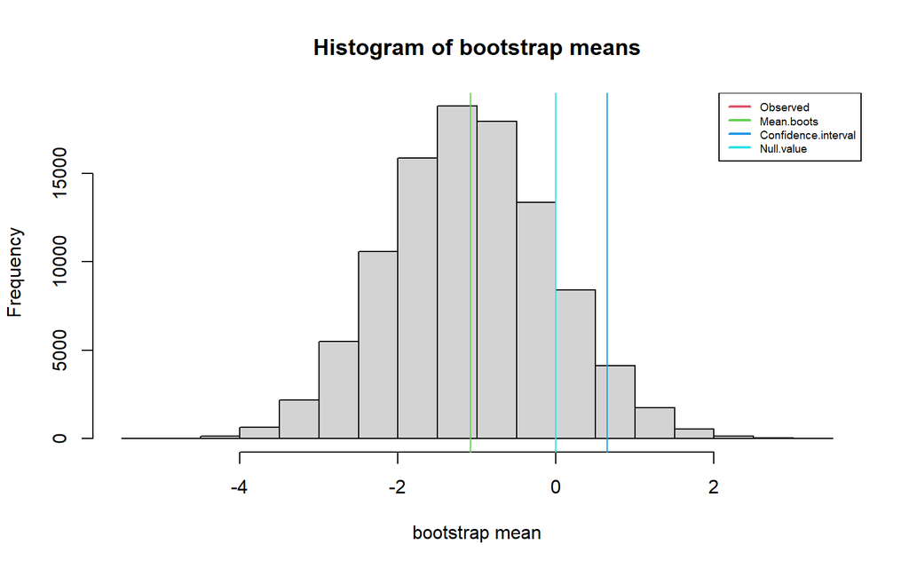

```
#>
#>
#>  RESULTS OF PERCENTILE BOOTSTRAP FOR MEAN
#>
#>     SUMMARY Variable  n Statistic  Observed
#>  STATISTICS        d 25      mean -1.085087
#>
#>  BOOTSTRAP Replications      Mean       SE  Bias Percent.bias
#>    SUMMARY        1e+05 -1.084287 1.038043 8e-04       0.0737
#>
#>  HYPOTHESIS Null Alternative P.value
#>        TEST    0   less-than    0.15
#>
#>  CONFIDENCE Level        Type Confidence.interval
#>    INTERVAL   95% upper-bound        0.6507 (UCB)
```

```r
b.Diff = wBoot::boot.one.per(d,
                             mean,
                             null.hyp=0,
                             alternative="less",
                             R=100000)
wBoot::print.boot.one(b.Diff)
```

La fonction **boot.paired.per** donnera évidemment des résultats similaires, en utilisant les données originales (x1 et y1):

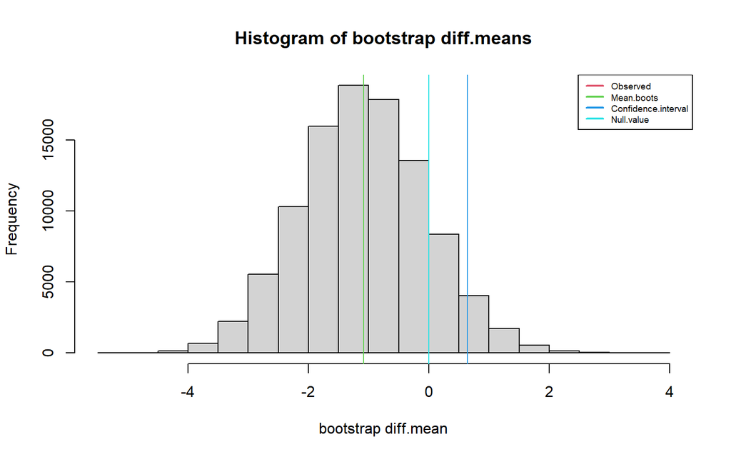

```
#>
#>
#>  RESULTS OF PERCENTILE BOOTSTRAP FOR DIFF.MEAN
#>
#>     SUMMARY Pop.1 Pop.2  n Statistic  Observed
#>  STATISTICS    x1    y1 25 diff.mean -1.085087
#>
#>  BOOTSTRAP Replications      Mean       SE     Bias Percent.bias
#>    SUMMARY        1e+05 -1.084196 1.037181 0.000891       0.0821
#>
#>  HYPOTHESIS Null Alternative P.value
#>        TEST    0   less-than   0.148
#>
#>  CONFIDENCE Level        Type Confidence.interval
#>    INTERVAL   95% upper-bound        0.6422 (UCB)
```

```r
b.Diff = boot.paired.per(x1,
                         y1,
                         null.hyp = 0,
                         alternative = "less",
                         conf.level = 0.95,
                         R = 100000)
b.Diff
```

### 13.5.4 Test d’hypothèse: deux échantillons corrélés - Approche théorique

Pour les données définies dans l’exemple précédent, supposons qu’on tente de vérifier si l’enseignement a été profitable aux élèves, c’est-à-dire que la performance à la fin de la session a été meilleure qu’au début: la différence des moyennes devrait être négative.

Les hypothèses statistiques considérées dans ce cas sont:

- $H_0:\mu_{\bar d}=0$
- $H_1:\mu_{\bar d}<0$

L’application de l’approche théorique au test d’hypothèse visant la différence de moyennes corrélées implique soit la distribution normale lorsque $n$ est grand, ou plus généralement, la distribution de Student. Nous connaissons déjà l’erreur-standard de la moyenne des différences ($\sigma_{\bar d}$). Le problème se résume donc à évaluer la distance standardisée séparant $\bar d$ de $\mu_d$:

```r
t <- md / sdbar
```

$$t=\frac{{\bar d}-\mu_d}{s_{\bar d}} =\frac{-1.085-0}{1.06}= -1.024$$
et la probabilité d’obtenir un tel $t$ ou une valeur plus extrême, **si** $H_0$ est vraie est:

```r
pr <- pt(t, n-1)
cat("p = ", pr)
```

```
#> p =  0.1580059
```

La fonction **t.test()** de l’environnement de base de R permet ce type d’opération:

```r
t.test(x1, y1,
       alternative="less",
       mu=0,
       paired=TRUE,
       conf.level=0.95 )
```

```
#>
#>  Paired t-test
#>
#> data:  x1 and y1
#> t = -1.0241, df = 24, p-value = 0.158
#> alternative hypothesis: true mean difference is less than 0
#> 95 percent confidence interval:
#>       -Inf 0.7277254
#> sample estimates:
#> mean difference
#>       -1.085087
```

## 13.6 Exercices

### 13.6.1 Comparaison de moyennes I

Pourrait-il exister une différence, au niveau de la population, entre la performance moyenne des hommes et des femmes au test de HabilCog, dans le département des Nippes? Pour répondre à cette question, considérons des échantillons de 35 hommes et de 40 femmes.

```r
# Création des sous-populations
subpop = subset(HaitiPop,(DEPARTEMENT=="4"),c(GENRE,HabilCog))
subpopH = subset(subpop,GENRE=="M",HabilCog)
subpopF = subset(subpop,GENRE=="F",HabilCog)
# Création des échantillons
nH = 35
nF = 40
xechH = subpopH$HabilCog[sample(1:nrow(subpopH),nH,replace=FALSE)]
xechF = subpopF$HabilCog[sample(1:nrow(subpopF),nF,replace=FALSE)]
cat("Moyenne (Hommes) = ",mean(xechH))
```

```
#> Moyenne (Hommes) =  97.13921
```

```r
cat("Moyenne (Femmes) = ",mean(xechF))
```

```
#> Moyenne (Femmes) =  96.19189
```

Le diagramme suivant illustre et résume la situation:

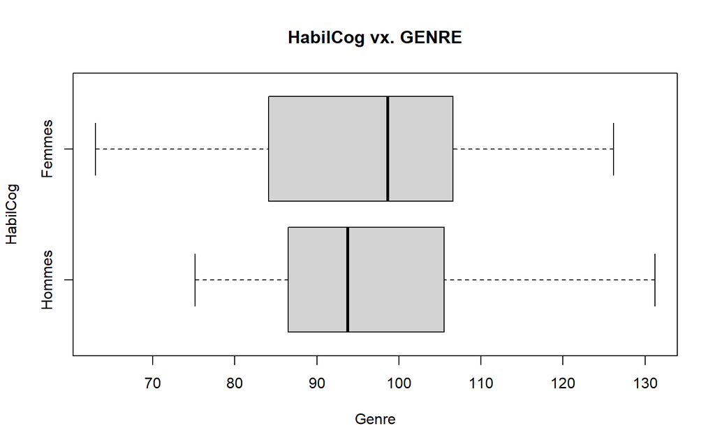

```r
boxplot(xechH,xechF, main="HabilCog vx. GENRE",
   xlab="Genre", ylab="HabilCog",horizontal=TRUE, names=c("Hommes","Femmes"))
```

Les moyennes des échantillons sont de toute évidence différentes, est-ce que cette différence est le simple fait de l’erreur d’échantillonnage, ou reflète-t-elle une différence réelle entre les moyennes des populations d’où ces échantillons ont été tirés?

Les hypothèses statistiques sont:

$H_0:\mu_{Hommes}-\mu_{Femmes}=0$

$H_0:\mu_{Hommes}-\mu_{Femmes}\neq0$

```r
#
# Ré-échantillonnage et distribution d'échantillonnage
#
library(wBoot)
b.Diff = boot.two.per(xechH,xechF,mean,null.hyp=0,alternative="two.sided",conf.level=0.95,R=100000,stacked=FALSE)
b.Diff
```

```
#>
#>
#>  RESULTS OF PERCENTILE BOOTSTRAP FOR DIFF.MEAN
#>
#>     SUMMARY Pop.1 Pop.2 n.1 n.2 Statistic  Observed
#>  STATISTICS xechH xechF  35  40 diff.mean 0.9473211
#>
#>  BOOTSTRAP Replications      Mean       SE     Bias Percent.bias
#>    SUMMARY        1e+05 0.9441145 3.344691 -0.00321        0.339
#>
#>  HYPOTHESIS Null Alternative P.value
#>        TEST    0   not-equal   0.787
#>
#>  CONFIDENCE Level      Type Confidence.interval
#>    INTERVAL   95% two-sided     (-5.462, 7.644)
```

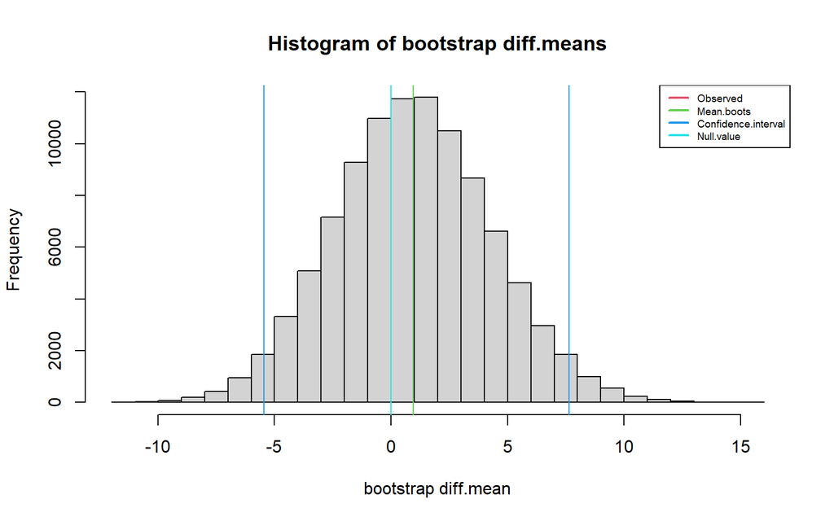

```
#>
#>
#>  RESULTS OF PERCENTILE BOOTSTRAP FOR DIFF.MEAN
#>
#>     SUMMARY Pop.1 Pop.2 n.1 n.2 Statistic  Observed
#>  STATISTICS xechH xechF  35  40 diff.mean 0.9473211
#>
#>  BOOTSTRAP Replications      Mean       SE     Bias Percent.bias
#>    SUMMARY        1e+05 0.9441145 3.344691 -0.00321        0.339
#>
#>  HYPOTHESIS Null Alternative P.value
#>        TEST    0   not-equal   0.787
#>
#>  CONFIDENCE Level      Type Confidence.interval
#>    INTERVAL   95% two-sided     (-5.462, 7.644)
```

```r
print.boot.two(b.Diff)
```

```r
p = b.Diff$p.value
```

Les résultats indiquent que la différence observée entre les moyennes des deux échantillons (hommes et femmes) est un événement probable (p = 0.787 ). Ce résultat va dans le sens de ce que propose $H_0$. On ne peut pas rejeter cette hypothèse. La différence observée ne reflète pas une réalité au niveau de la population, et on la considère comme statistiquement non significative . Il n’y a pas évidence voulant que la performance des hommes au test d’HabilCog diffère de celle des femmes.

### 13.6.2 Comparaison de moyennes II

Est-ce qu’il y a une différence entre l’indice de criminalité chez les hommes vivant en Artibonite et ceux vivant dans le département du Centre? On peut disposer d’un échantillon de 50 sujets en Artibonite, et de 45 sujets dans le département du Centre pour examiner la question.

```r
# Création des sous-populations
subpopA = subset(HaitiPop,((DEPARTEMENT=="1")&(GENRE=="M")&(AGE>=15)),CRIMIDX)
subpopC = subset(HaitiPop,((DEPARTEMENT=="2")&(GENRE=="M")&(AGE>=15)),CRIMIDX)

# Création des échantillons
nA = 50
nC = 45
xechA = subpopA$CRIMIDX[sample(1:nrow(subpopA),nA,replace=FALSE)]
xechC = subpopC$CRIMIDX[sample(1:nrow(subpopC),nC,replace=FALSE)]
cat("Moyenne (Artibonite) = ",mean(xechA))
```

```
#> Moyenne (Artibonite) =  143.4465
```

```r
cat("Moyenne (Centre)     = ",mean(xechC))
```

```
#> Moyenne (Centre)     =  95.49186
```

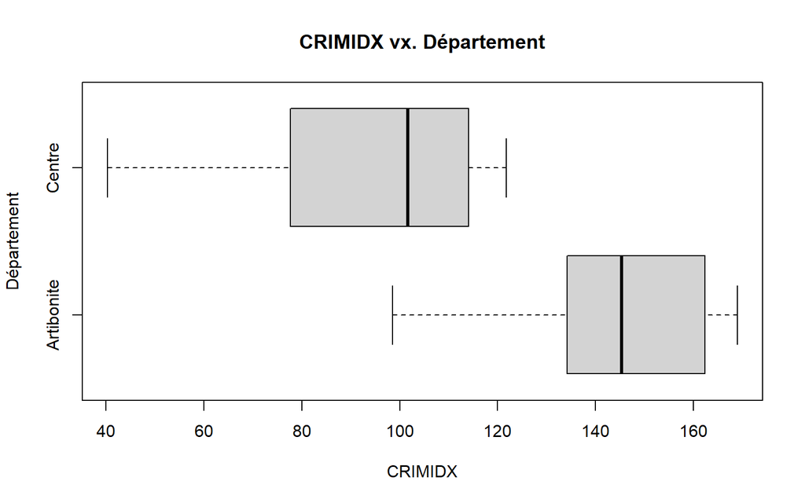

```r
boxplot(xechA,xechC, main="CRIMIDX vx. Département",
   xlab="CRIMIDX", ylab="Département",horizontal=TRUE, names=c("Artibonite","Centre"))
```

On constate que les deux moyennes échantillonnales sont différentes. Est-ce que cette différence est le simple fait de l’erreur d’échantillonnage, ou reflète-t-elle une différence réelle entre les moyennes des populations d’où ces échantillons ont été tirés?

Les hypothèses statistiques sont:

$H_0:\mu_{Artibonite}-\mu_{Centre}=0$

$H_0:\mu_{Artibonite}-\mu_{Centre}\neq0$

```r
#
# Ré-échantillonnage et distribution d'échantillonnage
#
library(wBoot)
b.Diff = boot.two.per(xechA,xechC,mean,null.hyp=0,alternative="two.sided",conf.level=0.95,R=100000,stacked=FALSE)
b.Diff
```

```
#>
#>
#>  RESULTS OF PERCENTILE BOOTSTRAP FOR DIFF.MEAN
#>
#>     SUMMARY Pop.1 Pop.2 n.1 n.2 Statistic Observed
#>  STATISTICS xechA xechC  50  45 diff.mean 47.95467
#>
#>  BOOTSTRAP Replications     Mean       SE    Bias Percent.bias
#>    SUMMARY        1e+05 47.96284 4.148829 0.00817        0.017
#>
#>  HYPOTHESIS Null Alternative   P.value
#>        TEST    0   not-equal P < 0.001
#>
#>  CONFIDENCE Level      Type Confidence.interval
#>    INTERVAL   95% two-sided      (39.91, 56.16)
```

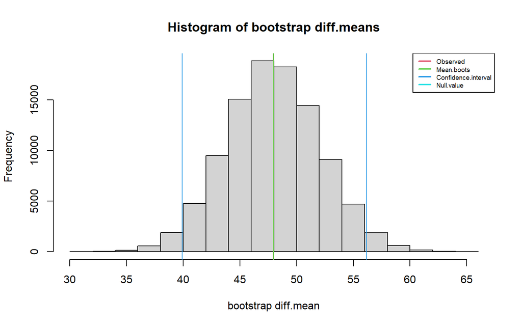

```
#>
#>
#>  RESULTS OF PERCENTILE BOOTSTRAP FOR DIFF.MEAN
#>
#>     SUMMARY Pop.1 Pop.2 n.1 n.2 Statistic Observed
#>  STATISTICS xechA xechC  50  45 diff.mean 47.95467
#>
#>  BOOTSTRAP Replications     Mean       SE    Bias Percent.bias
#>    SUMMARY        1e+05 47.96284 4.148829 0.00817        0.017
#>
#>  HYPOTHESIS Null Alternative   P.value
#>        TEST    0   not-equal P < 0.001
#>
#>  CONFIDENCE Level      Type Confidence.interval
#>    INTERVAL   95% two-sided      (39.91, 56.16)
```

```r
print.boot.two(b.Diff)
```

```r
p = b.Diff$p.value
```

Les résultats indiquent que la différence observée entre les moyennes des deux échantillons (Artibonite et Centre) est un événement improbable (p = 10^{-5} ). Ce résultat va à l’encontre de ce que propose $H_0$. On peut rejeter cette hypothèse. La différence observée reflète une réalité au niveau de la population, et on la considère comme statistiquement significative . Il y a évidence voulant que l’indice moyen de criminalité en Artibonite diffère de celui du département du Centre.

### 13.6.3 Comparaison de deux proportions (Échantillons indépendants)

Considérez la proportion des femmes ayant l’intention de voter pour le Candidat B aux prochaines élections présidentielles. Est-ce que cette proportion diffère entre le département du Sud-Est et le département du Nord-Ouest?

### 13.6.4 Comparaison de deux écarts-types (Échantillons indépendants)

Est-ce que, à l’échelle du pays, la dispersion de l’indice de criminalité (CRIMIDX) varie selon le sexe des sujets?

### 13.6.5 Comparaison de moyennes (Échantillons corrélés)

L’appréciation d’un candidat à l’élection présidentielle est mesurée sur une échelle de 1(aucune affinité avec le candidat) à 50 (Confiance absolue pour le candidat), avant et après un débat politique public. Un échantillon de 50 sujets est formé afin d’examiner l’impact qu’a eu le débat sur la mesure d’appréciation. Les données sont générées à l’aide du code R suivant (prenez soin d’installer la librairie **MASS** au préalable):

```r
library(MASS)
n = 50
mu = c(15,12)
A = matrix(runif(4)*2-1, ncol=2)
sigma = matrix(c(82.7,-45.46,-45.46,34.36),nrow=2)
x = abs(round(mvrnorm(n=50, mu, sigma, empirical = TRUE)))
head(x)
```

```
#>      [,1] [,2]
#> [1,]   21    3
#> [2,]   31   10
#> [3,]    8   16
#> [4,]    6   19
#> [5,]    7   23
#> [6,]    8   16
```

```r
cat("Corrélation = ",cor(x)[1,2])
```

```
#> Corrélation =  -0.8359274
```

Est-ce que le débat public a eu un impact significatif sur l’appréciation du candidat?